# Computing tips for awesome research and an easy life

Robert Turner, University of Sheffield RSE Team September, 2021

# Acknowledgements

Contains elements from [Reproducible Research Data and Project Management in R](https://github.com/annakrystalli/rrresearchACCE20), by Anna Krystalli and from [Methods in Research Software Engineering](https://github.com/davidwilby/ResearchSoftwareMethods) by David Wilby.

# About me

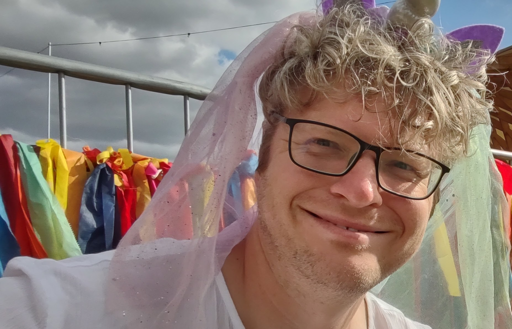

Bob Turner

Mix of software engineering and research experience.

# RSE Team

[figure not shown]

RSE

13 RSEs, 35 projects / year worth ~£11m total

# This presentation is flawed

Focusses on what to do, not how to do it.

# In this session…

# Discussion

> What are the characteristics of well engineered research software?

*Link to interactive doc*

# “Good” research software

- Version control
- Automated tests
- Controlled execution environment
- Documentation
- Parameterised

https://joss.readthedocs.io/en/latest/review_checklist.html

# Data Management

# Data Management Plan

- Start early. [Make an RDM](https://www.sheffield.ac.uk/library/rdm/dmp) plan before collecting data.
- Anticipate data products as part of your thesis outputs.
- Think about what technologies to use.

# Own your data

> Act as though every short term study will become a long term one [@tomjwebb](https://twitter.com/tomjwebb?ref_src=twsrc%5Etfw). Needs to be reproducible in 3, 20, 100 yrs

> — Oceans Initiative (@oceansresearch) [January 16, 2015](https://twitter.com/oceansresearch/status/556107891610894337?ref_src=twsrc%5Etfw)

Take initiative & responsibility. Think long term.

# Spreadsheets?

> [@tomjwebb](https://twitter.com/tomjwebb) stay away from excel at all costs?

> — Timothée Poisot (@tpoi) [January 16, 2015](https://twitter.com/tpoi/status/556107000950829056)

> Do you agree?

# Excel

> THRILLED by this announcement by the Human Gene Nomenclature Committee. [pic.twitter.com/BqLIOMm69d](https://t.co/BqLIOMm69d)

> — Janna Hutz (@jannahutz) [August 4, 2020](https://twitter.com/jannahutz/status/1290666010228514824?ref_src=twsrc%5Etfw)

But good for data viewing / entry, sometimes, perhaps…

# Databases

> [@tomjwebb](https://twitter.com/tomjwebb) Entering via a database management system (e.g., Access, Filemaker) can make entry easier & help prevent data entry errors [@tpoi](https://twitter.com/tpoi)

> — Ethan White (@ethanwhite) [January 16, 2015](https://twitter.com/ethanwhite/status/556119480493813760)

> [@ethanwhite](https://twitter.com/ethanwhite) +1 Enforcing data types, options from selection etc, just some useful things a DB gives you, if you turn them on [@tomjwebb](https://twitter.com/tomjwebb) [@tpoi](https://twitter.com/tpoi)

> — Gavin Simpson (@ucfagls) [January 16, 2015](https://twitter.com/ucfagls/status/556120176748290048)

> [@tomjwebb](https://twitter.com/tomjwebb) it also prevents a lot of different bad practices. It is possible to do some of this in Excel. [@tpoi](https://twitter.com/tpoi)

> — Ethan White (@ethanwhite) [January 16, 2015](https://twitter.com/ethanwhite/status/556119826582605824)

Have a look at the Data Carpentry [**SQL for Ecology** lesson](http://www.datacarpentry.org/sql-ecology-lesson/)

# Data formats

- **`.csv`**: *comma* separated values.
- **`.tsv`**: *tab* separated values.
- **`.txt`**: no formatting specified.

> [@tomjwebb](https://twitter.com/tomjwebb) It has to be interoperability/openness - can I read your data with whatever I use, without having to convert it?

> — Paul Swaddle (@paul_swaddle) [January 16, 2015](https://twitter.com/paul_swaddle/status/556148166270406656)

**more unusual formats will need instructions on use.**

# Ensure data is machine readable

# bad

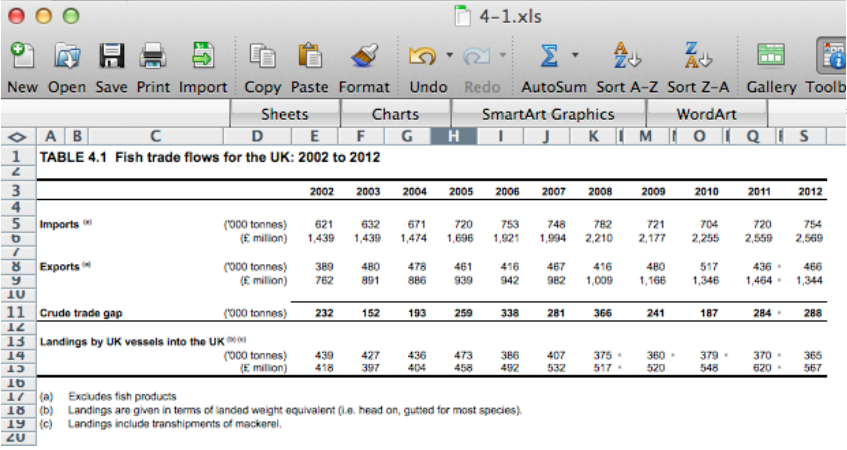

# bad

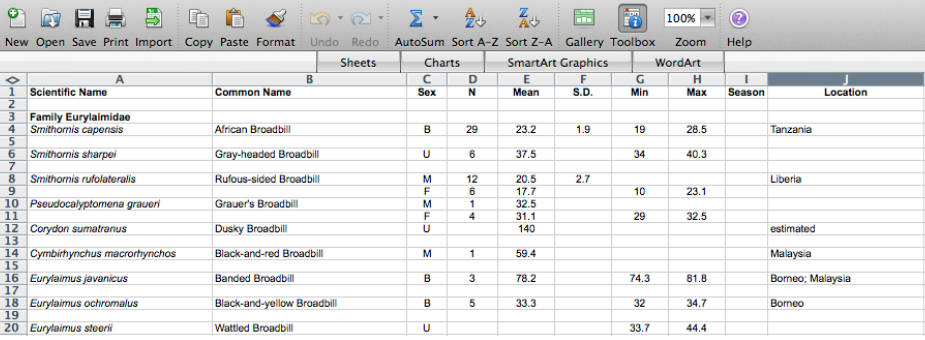

# good

[figure not shown]

# ok

[figure not shown]

- could help data entry
- `.csv` or `.tsv` copy would need to be saved.